We will look at technique to find relation and correlation between 2 variables. The correlation coefficient is only able to tell if there exists a linear relationship, so we need to visualize the data so we don’t miss non-linear relationships Copying the DataFrame in to a conveniently named one library(SDSFoundations)

```r
library(SDSFoundations)
bulls <- BullRiders
```

Creating a scatterplot between variables we wish to examine

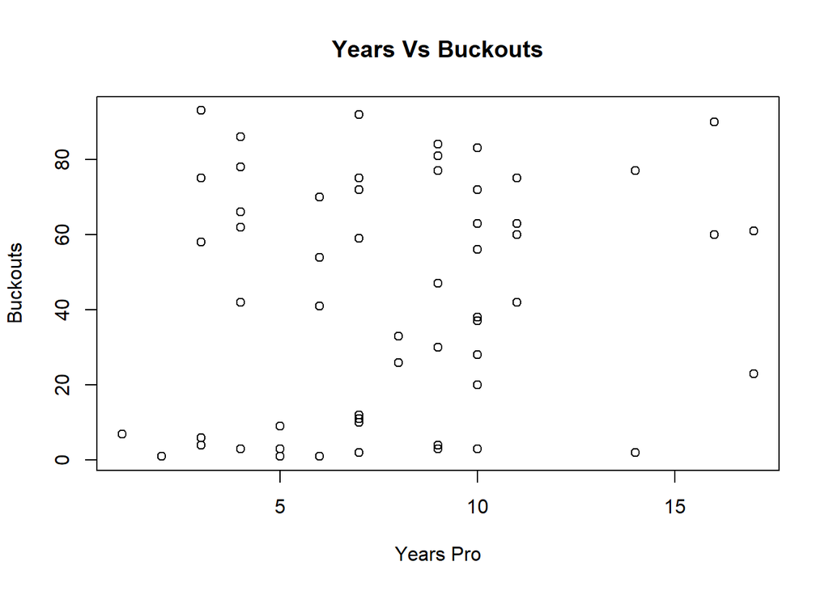

```r
plot(bulls$YearsPro,bulls$BuckOuts14, ylab='Buckouts',xlab = 'Years Pro', main= 'Years Vs Buckouts')
```

The dots are all over the place and the relation is not looking linear, let us confirm by tracing a line

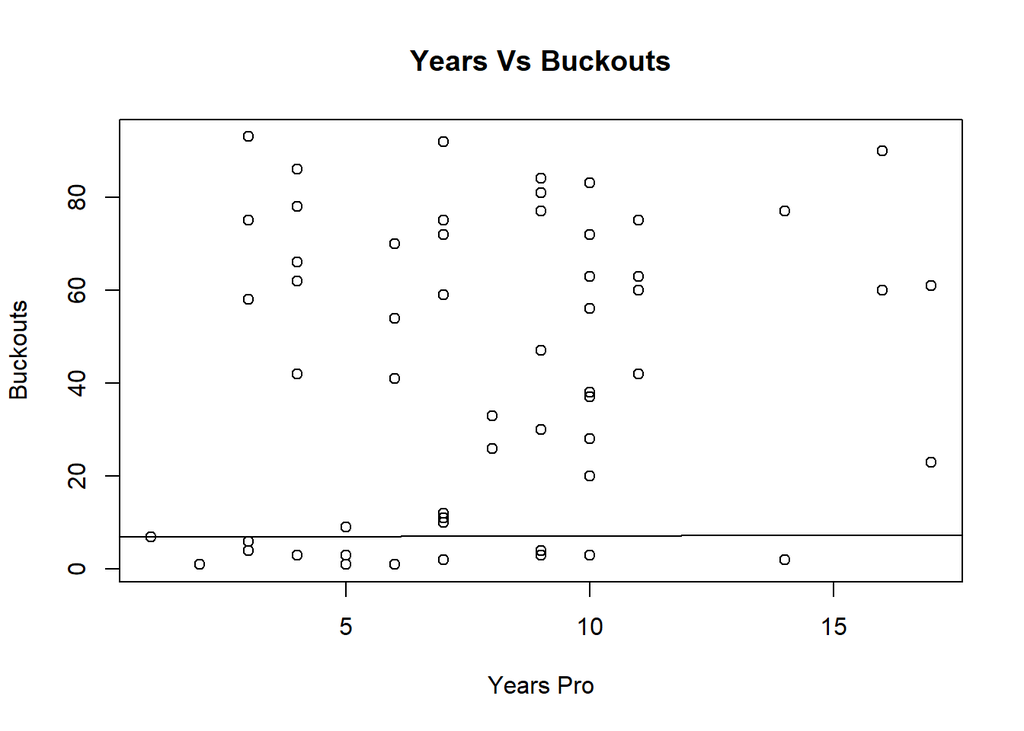

```
## integer(0)
```

```r
plot(bulls$YearsPro,bulls$BuckOuts14, ylab='Buckouts',xlab = 'Years Pro', main= 'Years Vs Buckouts')+
abline(lm(bulls$YearsPro~bulls$BuckOuts14))
```

We confirm that linear relationship doesn’t exist, we expect the correlation coefficient to be poor.

```r
cor(bulls$YearsPro,bulls$BuckOuts14)
```

```
## [1] 0.1870345
```

Let us try the same with Events held in 2014 and the respective Buckouts

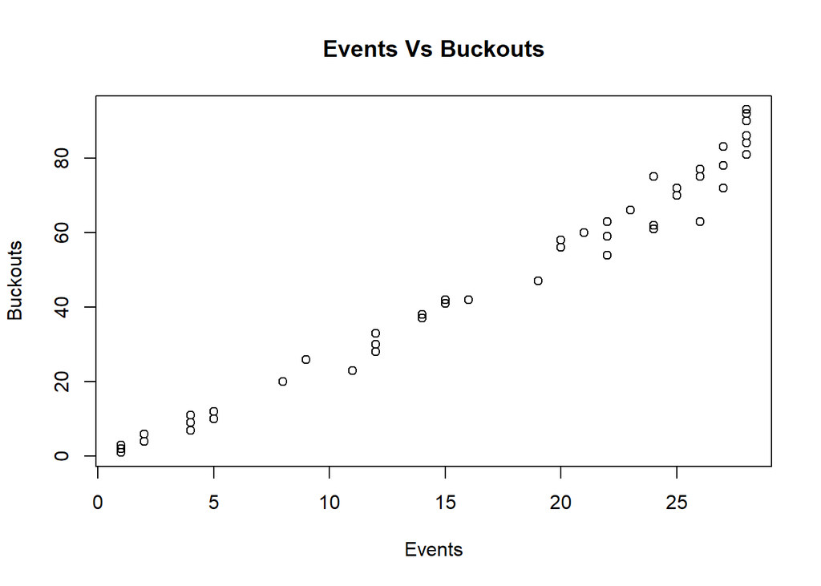

```r
plot(bulls$Events14,bulls$BuckOuts14, ylab='Buckouts',xlab = 'Events', main= 'Events Vs Buckouts')
```

Very strong relationship can be observed in scatterplot, let us confirm by calculation corr. coeff.

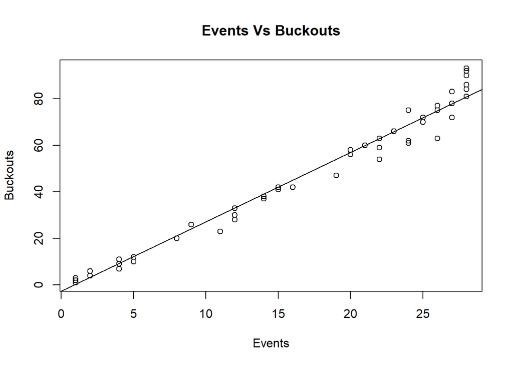

```
## integer(0)
```

```r
plot(bulls$Events14,bulls$BuckOuts14, ylab='Buckouts',xlab = 'Events', main= 'Events Vs Buckouts')+abline(lm(bulls$BuckOuts14~bulls$Events14))
```

```r
cor(bulls$Events14,bulls$BuckOuts14)
```

```
## [1] 0.9902185
```

Build a nice little table for quick correlation infor between variables. Storing the variables of interest in a vector

```r
corvar <- c('YearsPro','Events14','BuckOuts14')
```

Calculating correlatin between them, rounded to 2 digits

```r
round(cor(bulls[,corvar]),2)
```

```
##            YearsPro Events14 BuckOuts14
## YearsPro       1.00     0.22       0.19
## Events14       0.22     1.00       0.99
## BuckOuts14     0.19     0.99       1.00
```

*This analysis can say that there is a strong linear relation between the participation of a rider at event and the number of BuckOuts*